# Risk Factor Analysis

## Outcome Variable

**Outcome Variable:** ever_stunted

## Predictor Variables

**Intervention Variable:** month

**Adjustment Set:**

unadjusted

## Stratifying Variables

The analysis was stratified on these variable(s):

- agecat
- studyid

The following strata were considered:

- agecat: 12 months, studyid: ki0047075b-MAL-ED
- agecat: 12 months, studyid: ki1000108-CMC-V-BCS-2002
- agecat: 12 months, studyid: ki1000108-IRC
- agecat: 12 months, studyid: ki1000109-EE
- agecat: 12 months, studyid: ki1000109-ResPak
- agecat: 12 months, studyid: ki1000304b-SAS-FoodSuppl
- agecat: 12 months, studyid: ki1017093-NIH-Birth
- agecat: 12 months, studyid: ki1066203-TanzaniaChild2
- agecat: 12 months, studyid: ki1112895-Guatemala BSC
- agecat: 12 months, studyid: ki1113344-GMS-Nepal
- agecat: 12 months, studyid: ki1114097-CMIN
- agecat: 12 months, studyid: ki1114097-CONTENT
- agecat: 12 months, studyid: ki1126311-ZVITAMBO
- agecat: 12 months, studyid: ki1148112-LCNI-5
- agecat: 18 months, studyid: ki0047075b-MAL-ED
- agecat: 18 months, studyid: ki1000108-CMC-V-BCS-2002
- agecat: 18 months, studyid: ki1000108-IRC
- agecat: 18 months, studyid: ki1000109-EE
- agecat: 18 months, studyid: ki1000109-ResPak
- agecat: 18 months, studyid: ki1000304b-SAS-FoodSuppl
- agecat: 18 months, studyid: ki1017093-NIH-Birth
- agecat: 18 months, studyid: ki1066203-TanzaniaChild2
- agecat: 18 months, studyid: ki1112895-Guatemala BSC
- agecat: 18 months, studyid: ki1113344-GMS-Nepal
- agecat: 18 months, studyid: ki1114097-CMIN
- agecat: 18 months, studyid: ki1114097-CONTENT
- agecat: 18 months, studyid: ki1126311-ZVITAMBO
- agecat: 18 months, studyid: ki1148112-LCNI-5
- agecat: 24 months, studyid: ki0047075b-MAL-ED
- agecat: 24 months, studyid: ki1000108-CMC-V-BCS-2002
- agecat: 24 months, studyid: ki1000108-IRC
- agecat: 24 months, studyid: ki1000109-EE
- agecat: 24 months, studyid: ki1000304b-SAS-FoodSuppl
- agecat: 24 months, studyid: ki1017093-NIH-Birth
- agecat: 24 months, studyid: ki1066203-TanzaniaChild2
- agecat: 24 months, studyid: ki1113344-GMS-Nepal
- agecat: 24 months, studyid: ki1114097-CMIN
- agecat: 24 months, studyid: ki1114097-CONTENT
- agecat: 24 months, studyid: ki1126311-ZVITAMBO
- agecat: 24 months, studyid: ki1148112-LCNI-5
- agecat: 3 months, studyid: ki0047075b-MAL-ED
- agecat: 3 months, studyid: ki1000108-CMC-V-BCS-2002
- agecat: 3 months, studyid: ki1000108-IRC
- agecat: 3 months, studyid: ki1000109-EE
- agecat: 3 months, studyid: ki1000109-ResPak
- agecat: 3 months, studyid: ki1017093-NIH-Birth
- agecat: 3 months, studyid: ki1066203-TanzaniaChild2
- agecat: 3 months, studyid: ki1113344-GMS-Nepal
- agecat: 3 months, studyid: ki1114097-CMIN
- agecat: 3 months, studyid: ki1114097-CONTENT
- agecat: 3 months, studyid: ki1126311-ZVITAMBO
- agecat: 6 months, studyid: ki0047075b-MAL-ED
- agecat: 6 months, studyid: ki1000108-CMC-V-BCS-2002
- agecat: 6 months, studyid: ki1000108-IRC
- agecat: 6 months, studyid: ki1000109-EE
- agecat: 6 months, studyid: ki1000109-ResPak
- agecat: 6 months, studyid: ki1000304b-SAS-FoodSuppl
- agecat: 6 months, studyid: ki1017093-NIH-Birth
- agecat: 6 months, studyid: ki1066203-TanzaniaChild2
- agecat: 6 months, studyid: ki1112895-Guatemala BSC
- agecat: 6 months, studyid: ki1113344-GMS-Nepal
- agecat: 6 months, studyid: ki1114097-CMIN
- agecat: 6 months, studyid: ki1114097-CONTENT
- agecat: 6 months, studyid: ki1126311-ZVITAMBO
- agecat: 6 months, studyid: ki1148112-LCNI-5

### Dropped Strata

Some strata were dropped due to rare outcomes:

- agecat: 3 months, studyid: ki1000108-CMC-V-BCS-2002
- agecat: 3 months, studyid: ki1000109-EE
- agecat: 3 months, studyid: ki1000109-ResPak
- agecat: 3 months, studyid: ki1066203-TanzaniaChild2
- agecat: 3 months, studyid: ki1113344-GMS-Nepal
- agecat: 3 months, studyid: ki1114097-CONTENT
- agecat: 6 months, studyid: ki1000109-EE
- agecat: 6 months, studyid: ki1000109-ResPak
- agecat: 6 months, studyid: ki1000304b-SAS-FoodSuppl
- agecat: 6 months, studyid: ki1066203-TanzaniaChild2
- agecat: 6 months, studyid: ki1112895-Guatemala BSC
- agecat: 6 months, studyid: ki1113344-GMS-Nepal
- agecat: 6 months, studyid: ki1114097-CONTENT
- agecat: 6 months, studyid: ki1148112-LCNI-5
- agecat: 12 months, studyid: ki1000108-CMC-V-BCS-2002
- agecat: 12 months, studyid: ki1000109-EE
- agecat: 12 months, studyid: ki1000109-ResPak
- agecat: 12 months, studyid: ki1000304b-SAS-FoodSuppl
- agecat: 12 months, studyid: ki1112895-Guatemala BSC
- agecat: 12 months, studyid: ki1113344-GMS-Nepal
- agecat: 12 months, studyid: ki1114097-CONTENT
- agecat: 18 months, studyid: ki1000108-CMC-V-BCS-2002
- agecat: 18 months, studyid: ki1000109-EE
- agecat: 18 months, studyid: ki1000109-ResPak
- agecat: 18 months, studyid: ki1000304b-SAS-FoodSuppl
- agecat: 18 months, studyid: ki1066203-TanzaniaChild2
- agecat: 18 months, studyid: ki1112895-Guatemala BSC
- agecat: 18 months, studyid: ki1113344-GMS-Nepal
- agecat: 18 months, studyid: ki1114097-CONTENT
- agecat: 18 months, studyid: ki1148112-LCNI-5
- agecat: 24 months, studyid: ki1000108-CMC-V-BCS-2002
- agecat: 24 months, studyid: ki1000108-IRC
- agecat: 24 months, studyid: ki1000109-EE
- agecat: 24 months, studyid: ki1000304b-SAS-FoodSuppl
- agecat: 24 months, studyid: ki1066203-TanzaniaChild2
- agecat: 24 months, studyid: ki1113344-GMS-Nepal
- agecat: 24 months, studyid: ki1114097-CONTENT
- agecat: 24 months, studyid: ki1148112-LCNI-5

## Methods Detail

We’re interested in the causal parameters $E[Y_a]$ for all values of $a \in \mathcal{A}$. These parameters represent the mean outcome if, possibly contrary to fact, we intervened to set all units to have $A=a$. Under the randomization and positivity assumptions, these are identified by the statistical parameters $\psi_a=E_W[E_{Y|A,W}(Y|A=a,W)]$. In addition, we’re interested in the mean of $Y$, $E[Y]$ under no intervention (the observed mean). We will estimate these parameters by using SuperLearner to fit the relevant likelihood factors – $E_{Y|A,W}(Y|A=a,W)$ and $p(A=a|W)$, and then updating our likelihood fit using a joint TMLE.

For unadjusted analyses ($W=\{\}$), initial likelihoods were estimated using Lrnr_glm to estimate the simple $E(Y|A)$ and Lrnr_mean to estimate $p(A)$. For adjusted analyses, a small library containing Lrnr_glmnet, Lrnr_xgboost, and Lrnr_mean was used.

Having estimated these parameters, we will then use the delta method to estimate relative risks and attributable risks relative to a prespecified baseline level of $A$.

# Results Detail

## Results Plots

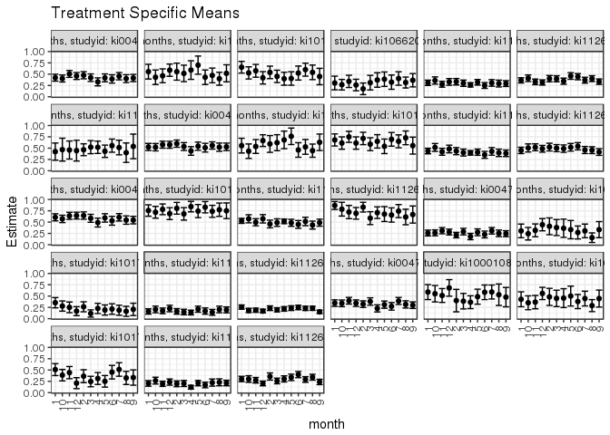

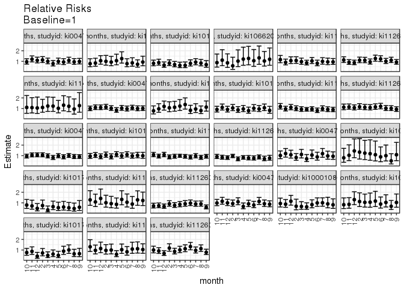

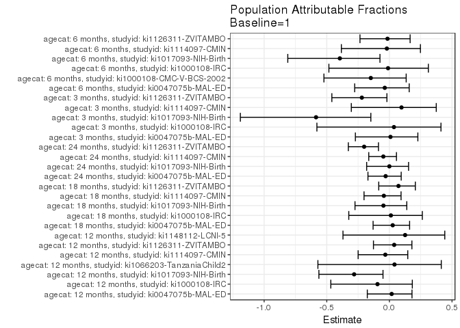

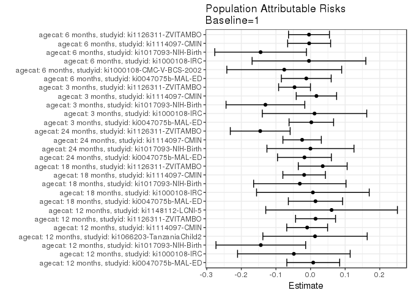

## Data Summary

| agecat | studyid | A | n | nA | nAY0 | nAY1 |
| --- | --- | --- | --- | --- | --- | --- |
| 3 months | ki0047075b-MAL-ED | 1 | 1868 | 178 | 132 | 46 |
| 3 months | ki0047075b-MAL-ED | 2 | 1868 | 174 | 137 | 37 |
| 3 months | ki0047075b-MAL-ED | 3 | 1868 | 149 | 106 | 43 |
| 3 months | ki0047075b-MAL-ED | 4 | 1868 | 116 | 95 | 21 |
| 3 months | ki0047075b-MAL-ED | 5 | 1868 | 135 | 98 | 37 |
| 3 months | ki0047075b-MAL-ED | 6 | 1868 | 119 | 92 | 27 |
| 3 months | ki0047075b-MAL-ED | 7 | 1868 | 159 | 110 | 49 |
| 3 months | ki0047075b-MAL-ED | 8 | 1868 | 139 | 104 | 35 |
| 3 months | ki0047075b-MAL-ED | 9 | 1868 | 164 | 124 | 40 |
| 3 months | ki0047075b-MAL-ED | 10 | 1868 | 175 | 129 | 46 |
| 3 months | ki0047075b-MAL-ED | 11 | 1868 | 174 | 120 | 54 |
| 3 months | ki0047075b-MAL-ED | 12 | 1868 | 186 | 134 | 52 |
| 3 months | ki1000108-CMC-V-BCS-2002 | 1 | 362 | 33 | 16 | 17 |
| 3 months | ki1000108-CMC-V-BCS-2002 | 2 | 362 | 15 | 12 | 3 |
| 3 months | ki1000108-CMC-V-BCS-2002 | 3 | 362 | 30 | 25 | 5 |
| 3 months | ki1000108-CMC-V-BCS-2002 | 4 | 362 | 43 | 35 | 8 |
| 3 months | ki1000108-CMC-V-BCS-2002 | 5 | 362 | 35 | 24 | 11 |
| 3 months | ki1000108-CMC-V-BCS-2002 | 6 | 362 | 35 | 22 | 13 |
| 3 months | ki1000108-CMC-V-BCS-2002 | 7 | 362 | 38 | 25 | 13 |
| 3 months | ki1000108-CMC-V-BCS-2002 | 8 | 362 | 17 | 11 | 6 |
| 3 months | ki1000108-CMC-V-BCS-2002 | 9 | 362 | 21 | 13 | 8 |
| 3 months | ki1000108-CMC-V-BCS-2002 | 10 | 362 | 29 | 19 | 10 |
| 3 months | ki1000108-CMC-V-BCS-2002 | 11 | 362 | 41 | 26 | 15 |
| 3 months | ki1000108-CMC-V-BCS-2002 | 12 | 362 | 25 | 9 | 16 |
| 3 months | ki1000108-IRC | 1 | 410 | 36 | 25 | 11 |
| 3 months | ki1000108-IRC | 2 | 410 | 27 | 16 | 11 |
| 3 months | ki1000108-IRC | 3 | 410 | 29 | 18 | 11 |
| 3 months | ki1000108-IRC | 4 | 410 | 22 | 14 | 8 |
| 3 months | ki1000108-IRC | 5 | 410 | 21 | 14 | 7 |
| 3 months | ki1000108-IRC | 6 | 410 | 37 | 27 | 10 |

[output cut: 810 more lines]

## Results Table

### Parameter: TSM

| agecat | studyid | intervention_level | baseline_level | estimate | ci_lower | ci_upper |
| --- | --- | --- | --- | --- | --- | --- |
| 3 months | ki0047075b-MAL-ED | 1 | NA | 0.2584270 | 0.1940989 | 0.3227550 |
| 3 months | ki0047075b-MAL-ED | 2 | NA | 0.2126437 | 0.1518299 | 0.2734574 |
| 3 months | ki0047075b-MAL-ED | 3 | NA | 0.2885906 | 0.2158173 | 0.3613639 |
| 3 months | ki0047075b-MAL-ED | 4 | NA | 0.1810345 | 0.1109456 | 0.2511233 |
| 3 months | ki0047075b-MAL-ED | 5 | NA | 0.2740741 | 0.1988118 | 0.3493364 |
| 3 months | ki0047075b-MAL-ED | 6 | NA | 0.2268908 | 0.1516211 | 0.3021604 |
| 3 months | ki0047075b-MAL-ED | 7 | NA | 0.3081761 | 0.2363862 | 0.3799660 |
| 3 months | ki0047075b-MAL-ED | 8 | NA | 0.2517986 | 0.1796226 | 0.3239746 |
| 3 months | ki0047075b-MAL-ED | 9 | NA | 0.2439024 | 0.1781610 | 0.3096439 |
| 3 months | ki0047075b-MAL-ED | 10 | NA | 0.2628571 | 0.1976221 | 0.3280922 |
| 3 months | ki0047075b-MAL-ED | 11 | NA | 0.3103448 | 0.2415861 | 0.3791036 |
| 3 months | ki0047075b-MAL-ED | 12 | NA | 0.2795699 | 0.2150566 | 0.3440832 |
| 3 months | ki1000108-IRC | 1 | NA | 0.3055556 | 0.1548980 | 0.4562131 |
| 3 months | ki1000108-IRC | 2 | NA | 0.4074074 | 0.2218454 | 0.5929694 |
| 3 months | ki1000108-IRC | 3 | NA | 0.3793103 | 0.2024974 | 0.5561233 |
| 3 months | ki1000108-IRC | 4 | NA | 0.3636364 | 0.1623783 | 0.5648945 |
| 3 months | ki1000108-IRC | 5 | NA | 0.3333333 | 0.1314677 | 0.5351990 |
| 3 months | ki1000108-IRC | 6 | NA | 0.2702703 | 0.1269995 | 0.4135411 |
| 3 months | ki1000108-IRC | 7 | NA | 0.3055556 | 0.1548980 | 0.4562131 |
| 3 months | ki1000108-IRC | 8 | NA | 0.1555556 | 0.0495325 | 0.2615786 |
| 3 months | ki1000108-IRC | 9 | NA | 0.3333333 | 0.1553045 | 0.5113621 |
| 3 months | ki1000108-IRC | 10 | NA | 0.2432432 | 0.1048305 | 0.3816560 |
| 3 months | ki1000108-IRC | 11 | NA | 0.3170732 | 0.1744621 | 0.4596843 |
| 3 months | ki1000108-IRC | 12 | NA | 0.4423077 | 0.3071514 | 0.5774640 |
| 3 months | ki1017093-NIH-Birth | 1 | NA | 0.3529412 | 0.2392669 | 0.4666154 |
| 3 months | ki1017093-NIH-Birth | 2 | NA | 0.2622951 | 0.1518198 | 0.3727704 |
| 3 months | ki1017093-NIH-Birth | 3 | NA | 0.1147541 | 0.0347072 | 0.1948010 |
| 3 months | ki1017093-NIH-Birth | 4 | NA | 0.2264151 | 0.1136532 | 0.3391770 |
| 3 months | ki1017093-NIH-Birth | 5 | NA | 0.1914894 | 0.0789097 | 0.3040690 |
| 3 months | ki1017093-NIH-Birth | 6 | NA | 0.2127660 | 0.0956684 | 0.3298635 |

[output cut: 294 more lines]

### Parameter: E(Y)

| agecat | studyid | intervention_level | baseline_level | estimate | ci_lower | ci_upper |
| --- | --- | --- | --- | --- | --- | --- |
| 3 months | ki0047075b-MAL-ED | NA | NA | 0.2607066 | 0.2591058 | 0.2623075 |
| 3 months | ki1000108-IRC | NA | NA | 0.3170732 | 0.3092453 | 0.3249010 |
| 3 months | ki1017093-NIH-Birth | NA | NA | 0.2225755 | 0.2175144 | 0.2276367 |
| 3 months | ki1114097-CMIN | NA | NA | 0.1759494 | 0.1745447 | 0.1773540 |
| 3 months | ki1126311-ZVITAMBO | NA | NA | 0.2102403 | 0.2091482 | 0.2113323 |
| 6 months | ki0047075b-MAL-ED | NA | NA | 0.3329519 | 0.3308619 | 0.3350420 |
| 6 months | ki1000108-CMC-V-BCS-2002 | NA | NA | 0.5122616 | 0.5029000 | 0.5216231 |
| 6 months | ki1000108-IRC | NA | NA | 0.4240196 | 0.4165201 | 0.4315191 |
| 6 months | ki1017093-NIH-Birth | NA | NA | 0.3647913 | 0.3565691 | 0.3730135 |
| 6 months | ki1114097-CMIN | NA | NA | 0.1996762 | 0.1979869 | 0.2013655 |
| 6 months | ki1126311-ZVITAMBO | NA | NA | 0.2972381 | 0.2950787 | 0.2993974 |
| 12 months | ki0047075b-MAL-ED | NA | NA | 0.4301775 | 0.4281551 | 0.4321999 |
| 12 months | ki1000108-IRC | NA | NA | 0.5073529 | 0.4998405 | 0.5148654 |
| 12 months | ki1017093-NIH-Birth | NA | NA | 0.5101664 | 0.5034360 | 0.5168967 |
| 12 months | ki1066203-TanzaniaChild2 | NA | NA | 0.3185484 | 0.3133998 | 0.3236970 |
| 12 months | ki1114097-CMIN | NA | NA | 0.2995575 | 0.2983539 | 0.3007612 |
| 12 months | ki1126311-ZVITAMBO | NA | NA | 0.3778040 | 0.3761188 | 0.3794892 |
| 12 months | ki1148112-LCNI-5 | NA | NA | 0.4838710 | 0.4793020 | 0.4884399 |
| 18 months | ki0047075b-MAL-ED | NA | NA | 0.5399381 | 0.5380909 | 0.5417852 |
| 18 months | ki1000108-IRC | NA | NA | 0.5623472 | 0.5531625 | 0.5715319 |
| 18 months | ki1017093-NIH-Birth | NA | NA | 0.6498994 | 0.6443543 | 0.6554445 |
| 18 months | ki1114097-CMIN | NA | NA | 0.4175210 | 0.4159289 | 0.4191131 |
| 18 months | ki1126311-ZVITAMBO | NA | NA | 0.4854526 | 0.4838164 | 0.4870888 |
| 24 months | ki0047075b-MAL-ED | NA | NA | 0.5876623 | 0.5853945 | 0.5899302 |
| 24 months | ki1017093-NIH-Birth | NA | NA | 0.7553191 | 0.7508358 | 0.7598025 |
| 24 months | ki1114097-CMIN | NA | NA | 0.5029970 | 0.5013868 | 0.5046073 |
| 24 months | ki1126311-ZVITAMBO | NA | NA | 0.7212766 | 0.7135021 | 0.7290511 |

### Parameter: RR

| agecat | studyid | intervention_level | baseline_level | estimate | ci_lower | ci_upper |
| --- | --- | --- | --- | --- | --- | --- |
| 3 months | ki0047075b-MAL-ED | 2 | 1 | 0.8228386 | 0.5631884 | 1.2021969 |
| 3 months | ki0047075b-MAL-ED | 3 | 1 | 1.1167202 | 0.7835384 | 1.5915799 |
| 3 months | ki0047075b-MAL-ED | 4 | 1 | 0.7005247 | 0.4421084 | 1.1099878 |
| 3 months | ki0047075b-MAL-ED | 5 | 1 | 1.0605475 | 0.7320916 | 1.5363665 |
| 3 months | ki0047075b-MAL-ED | 6 | 1 | 0.8779686 | 0.5799041 | 1.3292349 |
| 3 months | ki0047075b-MAL-ED | 7 | 1 | 1.1925075 | 0.8480090 | 1.6769564 |
| 3 months | ki0047075b-MAL-ED | 8 | 1 | 0.9743510 | 0.6665619 | 1.4242636 |
| 3 months | ki0047075b-MAL-ED | 9 | 1 | 0.9437964 | 0.6539383 | 1.3621341 |
| 3 months | ki0047075b-MAL-ED | 10 | 1 | 1.0171429 | 0.7156927 | 1.4455641 |
| 3 months | ki0047075b-MAL-ED | 11 | 1 | 1.2008996 | 0.8605624 | 1.6758341 |
| 3 months | ki0047075b-MAL-ED | 12 | 1 | 1.0818139 | 0.7704433 | 1.5190233 |
| 3 months | ki1000108-IRC | 2 | 1 | 1.3333333 | 0.6814329 | 2.6088816 |
| 3 months | ki1000108-IRC | 3 | 1 | 1.2413793 | 0.6298310 | 2.4467239 |
| 3 months | ki1000108-IRC | 4 | 1 | 1.1900826 | 0.5671051 | 2.4974150 |
| 3 months | ki1000108-IRC | 5 | 1 | 1.0909091 | 0.4996127 | 2.3820103 |
| 3 months | ki1000108-IRC | 6 | 1 | 0.8845209 | 0.4288412 | 1.8243985 |
| 3 months | ki1000108-IRC | 7 | 1 | 1.0000000 | 0.4979310 | 2.0083104 |
| 3 months | ki1000108-IRC | 8 | 1 | 0.5090909 | 0.2195112 | 1.1806847 |
| 3 months | ki1000108-IRC | 9 | 1 | 1.0909091 | 0.5273606 | 2.2566771 |
| 3 months | ki1000108-IRC | 10 | 1 | 0.7960688 | 0.3749359 | 1.6902239 |
| 3 months | ki1000108-IRC | 11 | 1 | 1.0376940 | 0.5323862 | 2.0226084 |
| 3 months | ki1000108-IRC | 12 | 1 | 1.4475524 | 0.8104244 | 2.5855688 |
| 3 months | ki1017093-NIH-Birth | 2 | 1 | 0.7431694 | 0.4373374 | 1.2628710 |
| 3 months | ki1017093-NIH-Birth | 3 | 1 | 0.3251366 | 0.1507959 | 0.7010388 |
| 3 months | ki1017093-NIH-Birth | 4 | 1 | 0.6415094 | 0.3545050 | 1.1608703 |
| 3 months | ki1017093-NIH-Birth | 5 | 1 | 0.5425532 | 0.2775300 | 1.0606565 |
| 3 months | ki1017093-NIH-Birth | 6 | 1 | 0.6028369 | 0.3186116 | 1.1406123 |
| 3 months | ki1017093-NIH-Birth | 7 | 1 | 0.5312500 | 0.2714030 | 1.0398802 |
| 3 months | ki1017093-NIH-Birth | 8 | 1 | 0.4612403 | 0.2176701 | 0.9773627 |
| 3 months | ki1017093-NIH-Birth | 9 | 1 | 0.5833333 | 0.2797118 | 1.2165298 |

[output cut: 267 more lines]

### Parameter: PAR

| agecat | studyid | intervention_level | baseline_level | estimate | ci_lower | ci_upper |
| --- | --- | --- | --- | --- | --- | --- |
| 3 months | ki0047075b-MAL-ED | 1 | NA | 0.0022797 | -0.0620683 | 0.0666276 |
| 3 months | ki1000108-IRC | 1 | NA | 0.0115176 | -0.1393432 | 0.1623784 |
| 3 months | ki1017093-NIH-Birth | 1 | NA | -0.1303657 | -0.2441525 | -0.0165788 |
| 3 months | ki1114097-CMIN | 1 | NA | 0.0170090 | -0.0413427 | 0.0753607 |
| 3 months | ki1126311-ZVITAMBO | 1 | NA | -0.0462439 | -0.0922106 | -0.0002772 |
| 6 months | ki0047075b-MAL-ED | 1 | NA | -0.0122862 | -0.0842314 | 0.0596591 |
| 6 months | ki1000108-CMC-V-BCS-2002 | 1 | NA | -0.0759737 | -0.2418918 | 0.0899443 |
| 6 months | ki1000108-IRC | 1 | NA | -0.0045518 | -0.1688725 | 0.1597689 |
| 6 months | ki1017093-NIH-Birth | 1 | NA | -0.1442996 | -0.2767939 | -0.0118053 |
| 6 months | ki1114097-CMIN | 1 | NA | -0.0040275 | -0.0660866 | 0.0580316 |
| 6 months | ki1126311-ZVITAMBO | 1 | NA | -0.0044861 | -0.0636025 | 0.0546303 |
| 12 months | ki0047075b-MAL-ED | 1 | NA | 0.0078173 | -0.0685287 | 0.0841632 |
| 12 months | ki1000108-IRC | 1 | NA | -0.0482026 | -0.2108944 | 0.1144892 |
| 12 months | ki1017093-NIH-Birth | 1 | NA | -0.1436798 | -0.2732804 | -0.0140792 |
| 12 months | ki1066203-TanzaniaChild2 | 1 | NA | 0.0129928 | -0.1377208 | 0.1637064 |
| 12 months | ki1114097-CMIN | 1 | NA | -0.0097645 | -0.0687604 | 0.0492314 |
| 12 months | ki1126311-ZVITAMBO | 1 | NA | 0.0145081 | -0.0432166 | 0.0722329 |
| 12 months | ki1148112-LCNI-5 | 1 | NA | 0.0607940 | -0.1293991 | 0.2509872 |
| 18 months | ki0047075b-MAL-ED | 1 | NA | 0.0142971 | -0.0641071 | 0.0927012 |
| 18 months | ki1000108-IRC | 1 | NA | 0.0067916 | -0.1559855 | 0.1695688 |
| 18 months | ki1017093-NIH-Birth | 1 | NA | -0.0309517 | -0.1644679 | 0.1025646 |
| 18 months | ki1114097-CMIN | 1 | NA | -0.0184790 | -0.0799836 | 0.0430256 |
| 18 months | ki1126311-ZVITAMBO | 1 | NA | 0.0351908 | -0.0354045 | 0.1057861 |
| 24 months | ki0047075b-MAL-ED | 1 | NA | -0.0176008 | -0.0953647 | 0.0601631 |
| 24 months | ki1017093-NIH-Birth | 1 | NA | -0.0002364 | -0.1260141 | 0.1255413 |
| 24 months | ki1114097-CMIN | 1 | NA | -0.0243342 | -0.0798580 | 0.0311896 |
| 24 months | ki1126311-ZVITAMBO | 1 | NA | -0.1453901 | -0.2318457 | -0.0589344 |

### Parameter: PAF

| agecat | studyid | intervention_level | baseline_level | estimate | ci_lower | ci_upper |
| --- | --- | --- | --- | --- | --- | --- |
| 3 months | ki0047075b-MAL-ED | 1 | NA | 0.0087442 | -0.2715220 | 0.2272347 |
| 3 months | ki1000108-IRC | 1 | NA | 0.0363248 | -0.5788202 | 0.4117950 |
| 3 months | ki1017093-NIH-Birth | 1 | NA | -0.5857143 | -1.1900268 | -0.1481548 |
| 3 months | ki1114097-CMIN | 1 | NA | 0.0966697 | -0.3040084 | 0.3742328 |
| 3 months | ki1126311-ZVITAMBO | 1 | NA | -0.2199573 | -0.4594491 | -0.0197654 |
| 6 months | ki0047075b-MAL-ED | 1 | NA | -0.0369007 | -0.2771562 | 0.1581586 |
| 6 months | ki1000108-CMC-V-BCS-2002 | 1 | NA | -0.1483104 | -0.5227156 | 0.1340361 |
| 6 months | ki1000108-IRC | 1 | NA | -0.0107349 | -0.4830508 | 0.3111598 |
| 6 months | ki1017093-NIH-Birth | 1 | NA | -0.3955676 | -0.8112775 | -0.0752682 |
| 6 months | ki1114097-CMIN | 1 | NA | -0.0201702 | -0.3835157 | 0.2477518 |
| 6 months | ki1126311-ZVITAMBO | 1 | NA | -0.0150926 | -0.2348041 | 0.1655252 |
| 12 months | ki0047075b-MAL-ED | 1 | NA | 0.0181722 | -0.1763527 | 0.1805299 |
| 12 months | ki1000108-IRC | 1 | NA | -0.0950081 | -0.4676597 | 0.1830241 |
| 12 months | ki1017093-NIH-Birth | 1 | NA | -0.2816332 | -0.5628632 | -0.0510092 |
| 12 months | ki1066203-TanzaniaChild2 | 1 | NA | 0.0407876 | -0.5707902 | 0.4142512 |
| 12 months | ki1114097-CMIN | 1 | NA | -0.0325964 | -0.2495776 | 0.1467073 |
| 12 months | ki1126311-ZVITAMBO | 1 | NA | 0.0384012 | -0.1271911 | 0.1796669 |
| 12 months | ki1148112-LCNI-5 | 1 | NA | 0.1256410 | -0.3706056 | 0.4422147 |
| 18 months | ki0047075b-MAL-ED | 1 | NA | 0.0264791 | -0.1301168 | 0.1613761 |
| 18 months | ki1000108-IRC | 1 | NA | 0.0120773 | -0.3242375 | 0.2629787 |
| 18 months | ki1017093-NIH-Birth | 1 | NA | -0.0476253 | -0.2746154 | 0.1389412 |
| 18 months | ki1114097-CMIN | 1 | NA | -0.0442589 | -0.2024695 | 0.0931357 |
| 18 months | ki1126311-ZVITAMBO | 1 | NA | 0.0724907 | -0.0849445 | 0.2070807 |
| 24 months | ki0047075b-MAL-ED | 1 | NA | -0.0299506 | -0.1711587 | 0.0942319 |
| 24 months | ki1017093-NIH-Birth | 1 | NA | -0.0003130 | -0.1814985 | 0.1530873 |
| 24 months | ki1114097-CMIN | 1 | NA | -0.0483784 | -0.1647903 | 0.0563990 |
| 24 months | ki1126311-ZVITAMBO | 1 | NA | -0.2015733 | -0.3278580 | -0.0872987 |